# Predicting Violence Against Women Using the Women’s Economic Opportunity Index (WEOI)

An exploration of the the main indicators of the WEOI and what they can tell us about violence against women

Reem Hazim , Lucas De Lellis , Lateefa Al AlRemeithi  
2021-12-17

# Introduction

Even though “[Achieving gender equality and empowering all women and girls” is among one of the 17 Sustainable Development Goals by the United Nations (United Nations), such goal swims against an enormous wave of violence against women in the contemporary world. Investigation on the causes of such violence is neither non-exhaustive nor simple. This paper aims to investigate what are possible reasons for the bugging persistence of violence against women, specifically positive attitudes towards violence against women. Believing in the importance of promoting women’s economic well-being in order to achieve equality, we aim to understand the relationship between violence against women and the Women’s Economic Opportunity Index (WEOI). Providing a violence-free environment for women and girls will immensely support their empowerment, which in turn represents countless gains for society as a whole (King 6).

After a brief literature review on the subject of women’s economic well-being, we explain our two-part methodology. Then, we present the data we obtained. Data was pulled from the Organisation for Economic Co-operation and Development (OECD), the United Nations (UN), and the World Bank (WB). Our analysis points out that even though women’s legal status seem to be one of the best predictors within the WEOI for violence against women, we must be attentive to ways in which indicators interact and affect each other.

# Literature Review

Women are disadvantaged in entrepreneurship. An assumption that institutions of entrepreneurship are genderless have resulted in structures that pretend to be “genderless” when they are not (Pathak et. al.). It is well-known that organizations, by not identifying or addressing the barriers that women might uniquely face, such as childrearing and domestic labour (Acker), have failed to provide equality in the workplace. Our research dialogues with previous literature in asserting that difficulty in women’s access to finance and labor participation further limit the possibility of firming women’s independence from, at best, their domestic and childrearing duties, and at worse, from their partners. By constraining women from participating in labor in equal and fair manners, as well accessing finance, we argue that this could be increasing violence against women.

Women’s education and legal status can both decrease levels of violence against women. When education is intentionally design to address gender inequality, awareness on violence against women have the potential to provide the tools women need to both identify and report when they are experience violence (Okenwa-Emgwa et. al.). Similarly, women’s legal status is important specially in what regards women having access to institutions and legal frameworks they can recur to when experiencing violence (Tavares & Wodon). This includes now only explicit regulation against violence experienced by intimate partners, but also legal frameworks protecting their right to freedom of movement, property ownership, adolescent fertility rate, and regulations addressing all forms of discrimination (Women’s Economic Opportunity Index). However, the literature has raised questions on the effectiveness of both of education and legal status alone raising the status of women and preventing violence. In terms of education, even though the benefits of education by itself are evident (Girl Rising), in order to effectively reduce violence against women, it is necessary to formulate curriculum that include gender equality and information on violence against women (Okenwa-Emgwa et. al.). In the case of women’s legal status, adequate implementation and observation of such laws are needed for the effective enforcement of laws (Tavares & Wodon). Our research dialogues with such limitations by exploring weather WEO’s indicators on education and training; and women’s legal status can adequately predict a decresed in a positive attitude against violence.

# Methodology

This study consists on two parts. The first part is an exploration of three variables that the Organisation for Economic Co-operation and Development (OECD) has linked to Violence Against Women. The first one is attitude towards violence, which consists on an indicator varying from 0-100% revealing the share of women who agree that a husband is justified in beating his wive(s). The second is prevalence of violence in lifetime (0-100%), which indicates the share of women exposed to physical and/or sexual violence at least one time from their intimate partner. Finally laws on domestic violence (0.25-1) measures whether legal frameworks protect women from domestic violence. The closer to 1, the more discriminatory the laws are against women.

Then, the second part of this research uses the Women’s Economic Opportunity Index (WEO) to predict violence against women.Created by Economist Intelligence Unit (research division of the Economist Group), “The Women’s Economic Opportunity Index is a dynamic quantitative and qualitative scoring model, constructed from 29 indicators, that measures specific attributes of the environment for women employees and entrepreneurs in 128 economies.” (Economist Inteliggence Union). The index is on a scale from 0 - 100, in which 0 refers to a least favourable situation to women and 100 refers to a more favourable situation to women.

We dissect the index into four out of its five main variables: labour participation, access to finance, women’s legal status, and women’s education and training, moving forward to using them as our independent variables. We finally move forward by focusing in attitude towards women as our dependent variable. We draw a causal graph that intends to predict what can be causing high levels of attitude towards violence. We then run several univariate and multivariate regression models were drawn between our dependent and independent variables.

# Theory/Hypotheses

With the literature in mind, and with a curiosity towards measurements taken by the Women’s Economic Opportunity Index, our research question consists on how do labour participation, women’s legal status, access to finance and women’s education and training appear to reduce or increase violence against women? Specifically, which one of those four variables seem to be the best predictor for an increase or reduction in attitude towards violence?

Even though we explore four out of the five indicators used in WEOI in order to possibly find out which indicators seem to best predict attitude towards violence, we also pay attention to the interactions between such indicators. We do so because we are well aware of possible confounding variables.

Labour participation consists in four indicators: equal pay for equal work, non-discrimination, degree of de facto discrimination against women in the workplace, and availability, affordability, and, quality of childcare services (Women’s Economic Opportunity Index Report 10).

Access to finance consists in four indicators: building credit histories, women’s access to finance programmes, delivering financial services, private-sector credit as a percent of Gross Domestic Product.(Women’s Economic Opportunity Index Report 11).

Education and training consists of four indicators: School life expectancy (primary and secondary), school life expectancy (tertiary), adult literacy rate, and existence of government or non-government programmes offering small and medium-sized enterprise (SME) support/development training.(Women’s Economic Opportunity Index Report 11).

Women’s legal status consists of five indicators: existence of laws protecting women against violence, freedom of movement, property ownership rights, adolescent fertility rate, and wether a country ratification of the Convention on the Elimination of All Forms of Discrimination against Women (CEDAW) (Women’s Economic Opportunity Index Report 11).

# Data

## Part 1: Exploration of Dependent Variables

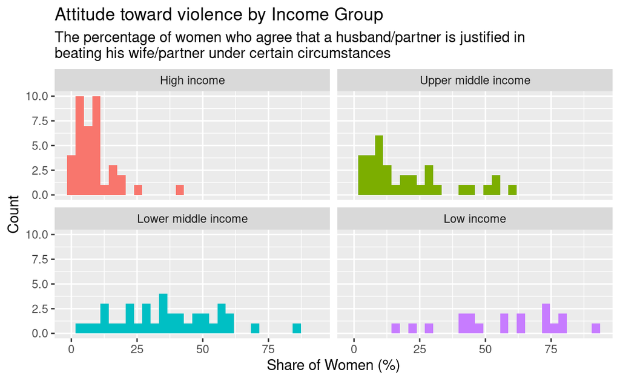

There seems to be a clear association between attitude towards violence against women and a countries’ group income. High and upper middle income countries seem to have a lower share of women who agree that the husband is justified in inflicted violence in their wives.

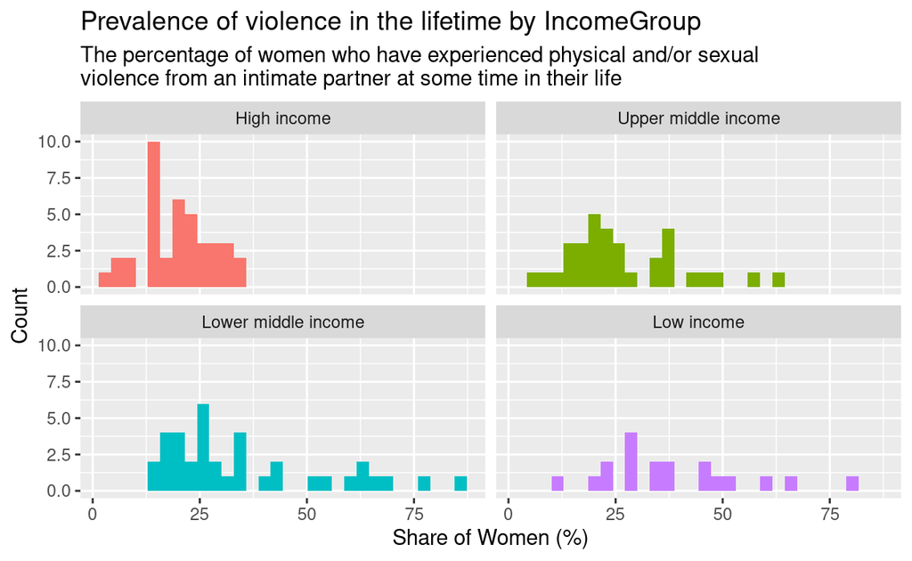

Similar to Attitudes Towards Violence, when it comes to prevalence of violence in the lifetime, we can observe that high income countries (colored red) are concentrated towards the left side of the graph. This means that fewer women have been exposed to physical or sexual violence in comparison to countries falling in other income groups.

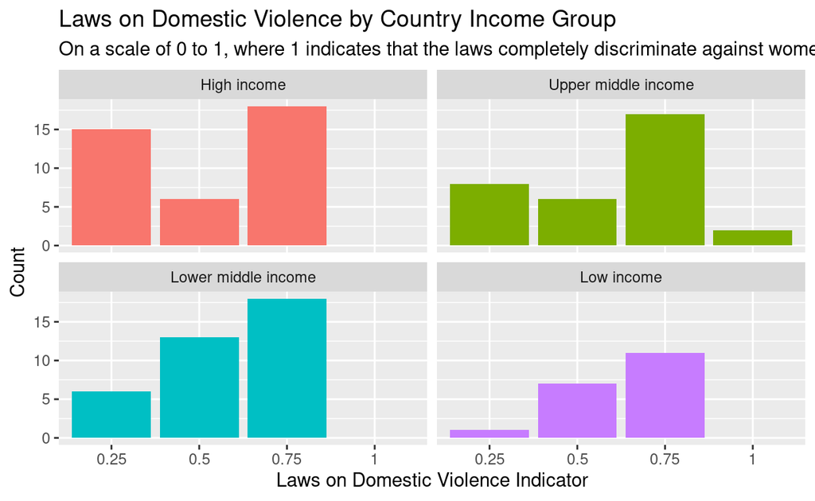

Whereas in regards to the previous variables it was clearer to see the distribution of data in regards to income group, Laws on domestic violence don’t see to follow the same pattern. The graph shows that most countries, regardless of income group, fall in the “0.75” measure for Laws on Domestic Violence. That means that their laws and practices are unsuficcient to garantee the well-being of women. It is evident that even though there are few countries in which the number reaches the value 1 (laws and practices are completely discriminatory against women), the realization that most countries in the global still have unsuficcient laws that protect women’s rights is incredibly worrying. We can also observe that there are more countries with better laws and practices for women’s rights among high income countries (that is, countries in which the indicator equals 0.25). This also holds true in a lesser extent for upper middle income countries. For both lower middle income and low income, however, there seems to be more countries in the 0.5 and 0.75 levels then in the 0.25. This unvels a pattern that establishes that higher income coutries, despite also having large number of countries that have a indicator of law on domestic violence equal to 0.75, have also higher number of countries that have a somewhat benefitial laws and practices against domestic violence. However, this does not seem to be a causal effect. It is highly unlikely that a countrie’s income group alone establishes the laws on domestic violence, but it points us in the direction of establishing a connection between higher levels of economic develpment and better legislation on domestic violence.

We proceed to design stacked bars in order to bette r understand patterns in the data, specially when it came to laws on domestic violence. However, one important aspect to notice is that the total number of countries in each income category will affect the visualization of these stack bars when they are not designed to take into acount proportion.

```
# A tibble: 4 × 2
  IncomeGroup         count
  <fct>               <int>
1 High income            39
2 Upper middle income    33
3 Lower middle income    37
4 Low income             19
```

There are 39 high income, 33 upper middle income, 37 lowe middle income, and only 19 lower income countries in the dataset.

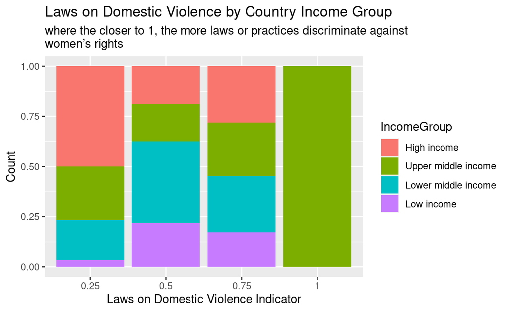

A stacked bar helps in the visualization and reveals that indeed most of the countries that have a value of 0.25 on Laws on Domestic Violence (better laws on domestic violence) are high income countries. However, it is important to notice that in the 0.75 value, there seems to be a more balanced distribution throughout all income groups. In the value of “1”, i.e., laws on domestic violence that completely discriminate against women, we find only upper middle income countries.

[figure not shown]

We also produced a bar stack for prevalence of violence in the lifetime, but instead of using a proportion stacked bar we opted for a frequency one. Even though this plot suffers from the total number of high income countries being superior overall, the concentration of such countries in the left side of the graph once again reveal the pattern of high income countries performing better in such indicators.

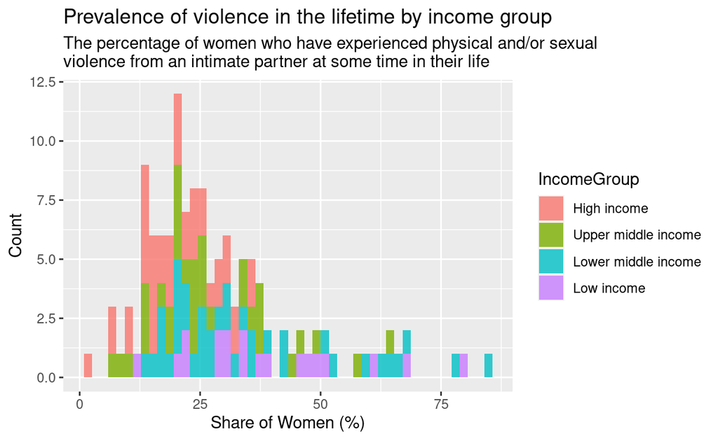

After drawing analysis by Income Group, a comparison between all three indicators unveiled their relationship among one another.

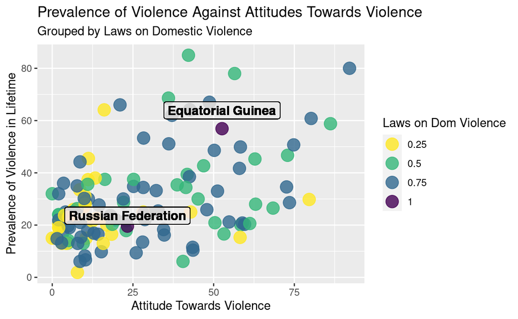

```
[1] 0.4489546
```

The annotated countries in the graph are countries in which the Laws Against Domestic Violence are completely discriminatory against women: Equatorial Guinea and the Russian Federation. Whereas Equatorial Guinea, besides a completely discriminatory Laws Against Domestic Violence, also has higher levels of Prevalence of Violence and Attitude Towards Violence, the Russian Federation is an interesting case. It shows lower levels of Prevalence of Violence and Attitude Towards Violence, but its legislation seem to completely discriminate against women. It is closer to the yellow dots on the graph, which are countries with good Laws on Domestic Violence. This sets Russia apart as an notable out liar when plotting the relationship between the three dependent variable. Research on its case will be interesting when analyzing potential causes for the persistence of violence against women.

### Comparing OECD and UN in Prevalence of Violence Againt Women

To determine whether the OECD indicator is an accurate representation of the prevalence of domestic violence against women, we decided to compare it to other available indicators on domestic violence. We have chosen the UN indicator, “Proportion of women subjected to physical and/or sexual violence by a current or former intimate partner in the last 12 months”.

There are some clear distinctions between the UN and OECD indicators. While they both measure the proportion of women who have experienced violence by an intimate partner, the UN indicator only includes women who have experienced violence in the past 12 months, while the OECD includes those who experienced violence at any point in their lives Therefore, we would expect the OECD indicator to be larger than the UN indicator for most countries, given that many more women would have experience violence at some point in their lives.

Another limitation is that the UN indicator comes from many different reference years. Some countries have collected this data in more recent years (2015), while others last collected this data in the year 2000. This discrepancy makes comparison between countries and between indicators more difficult, since peoples’ attitudes towards domestic violence and countries’ laws and regulations may have changed significantly over the years, potentially reducing the prevalence of domestic violence. In addition, all the data from the OECD indicator was collected in 2019, much more recently than most of the UN data. Nonetheless, it would be interesting to find out whether both indicators are consistent with each other.

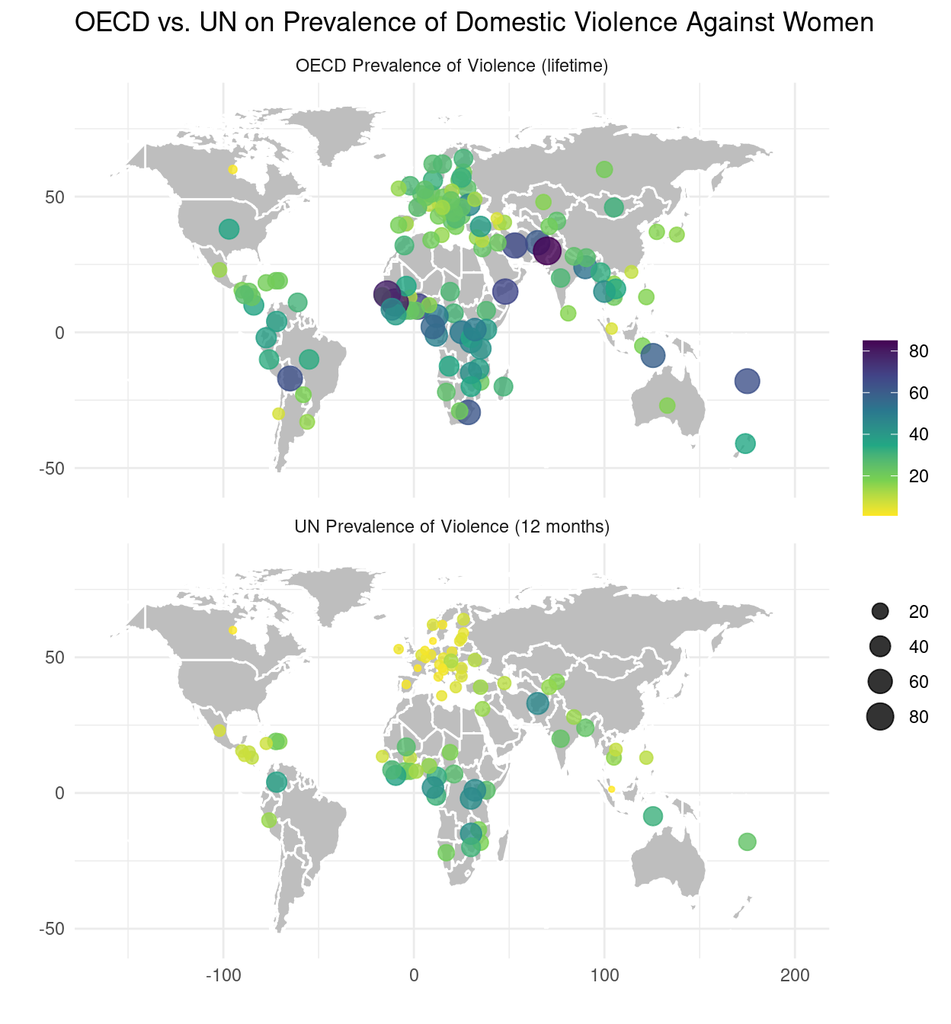

The figure above shows two maps of the world, with colored markers to represent the prevalence of violence in different countries. The first map visualizes the OECD indicator, while the second map visualizes the UN indicator. As expected, we can see that the OECD map has much darker and larger markers in general than the UN map, suggesting that the prevalence of violence is higher in the OECD data. This makes sense since the OECD measured the prevalence of violence over womens’ lifetimes, while the UN only measured violence in the past 12 months.

The two indicators also appear to be consistent across different regions. For instance, in both maps, Europe and Northern America appear to have less prevalence of domestic violence, as shown by the smaller, lighter markers. In contrast, markers across Africa, the Middle East and South America are consistently darker and larger, revealing patterns of higher prevalence of domestic violence.

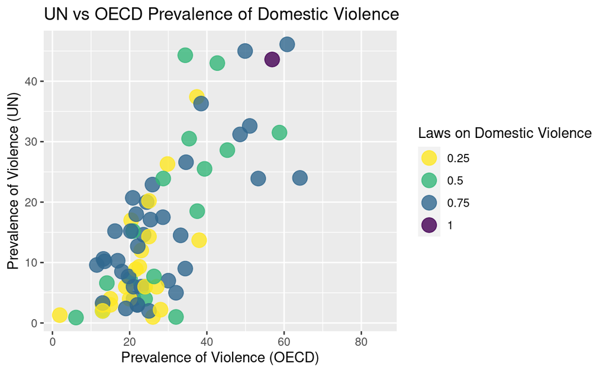

```
[1] 0.7561751
```

### Mapping Attitudes Towards Violence

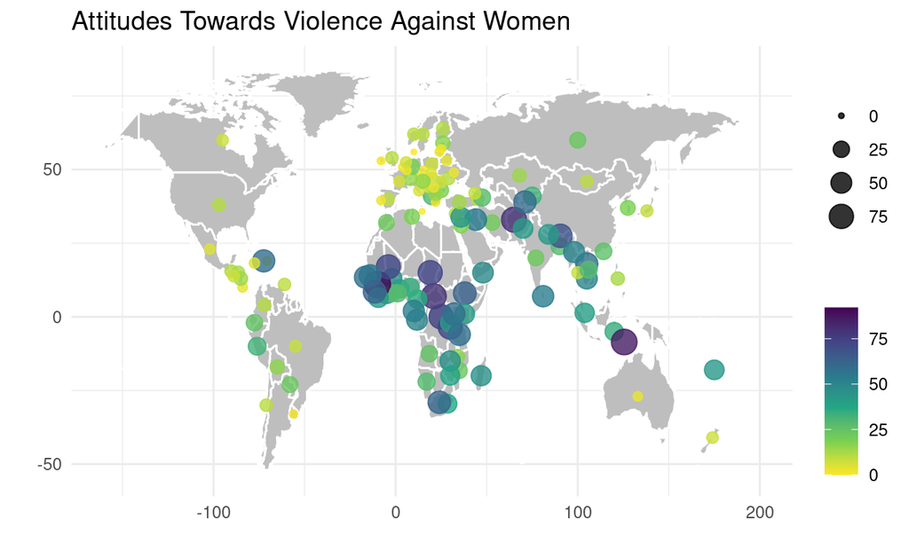

### Visualizing Independent Variables

[figure not shown]

### Issues with the Data and Limitations of Dependent Variables

For our dependent variables, we found some recurring data limitations.

Using Income Groups might reveal interesting patterns in what regards how differently countries with different income levels deal with violence against women, but it tells little about what are the causes of such discrepancies. Hence, whereas our graphs were helpful in revealing the path in which research can take, it did not necessary reveal to us what could be some of the causes for our indicators. Finally, using Income Group as a category might ignore nuances in regard to the socio-economic development of different countries. For example, countries like Brazil are classified as Upper Middle Income, but it also has one of the largest inequalities in the world (Gini Coefficient = 53.3), ranking 9th globally. Such incredible inequality could be driving some of our dependent variable, which separating countries by Income Group would not necessarily reveal.

One tidiness issue in the data is that the dataset is in long format, which makes it difficult to visualize the relationship between the different indicators. Therefore, we had to transform the dataset into wide format to create these plots.

There are also some discrepancies between what the indicators are trying to measure and what they actually measure. Quantifying such a large-scale phenomenon as violence against women is a non-trivial effort, since violence comes in many diverse forms. For example, the prevalence in lifetime indicator only quantifies violence from an intimate partner, excluding levels of harrasment that come from outside intimate circles, such as sex trafficking. Similarly, to measure “attitude towards violence”, the dataset creators used “the percentage of women who agree that a husband/partner is justified in beating his wife/partner under certain circumstances.” Why is this particular question used as a proxy for attitude towards violence? Why not ask whether non-intimate partners are also justified in beating women? Are there better or more comprehensive questions to gauge attitude towards violence?

In addition, for the “laws on domestic violence” indicator, the dataset creators do not explain how they quantified the abstract concept of “laws and practices”. They also do not specify what they mean by laws that “fully discriminate against women’s rights”. This makes it difficult to determine the accuracy of the indicator.

The dataset also does not contain all the countries in the world. We identifies 82 missing countries in our analysis.

If we perform an anti-join of the countries dataset with the violence dataset, we can see that there are around 82 missing countries. Most of these countries are small islands that may not have enough data on violence against women.

## Part 2: Predicting Attitude Towards Violence

Having explored out dependent variables, we proceed to exploring the relationship between out dependent variables and our chosen independent variable – The Women’s Economic Opportunity Index. (WOEI)

# Correlation Coefficients

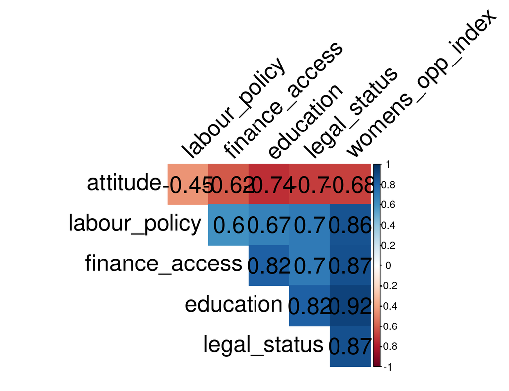

The matrix reveals that attitude towards women seem to negatively correlated with many of the indicators in the WEOI, especially education and training. However, it also evident that the indicators seem to be strongly correlated positively with each other as well. Such interactions could turn difficult to see confounding variables in our study.

```
           [,1]
attitude  -0.67
law       -0.16
prev_viol -0.41
```

From drawing correlations between the WEOI’s and the dependent variables, we notice that Attitude Towards Violence seems to offer the highest level of correlation (-0.67). For that reasons, we continue our analysis focusing on this variable in specific. Having chosen to focus on Attitude towards violence, we drew a causal diagram schematizing what can be the causes of higher levels of attitude towards violence.

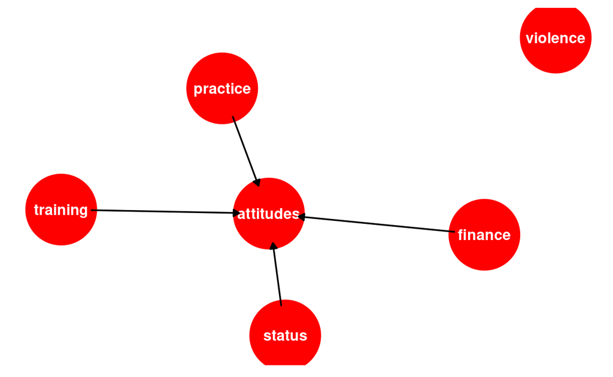

```
 Family: gaussian
  Links: mu = identity; sigma = identity
Formula: prev_viol ~ womens_opp_index
   Data: relevant_factors (Number of observations: 102)
  Draws: 4 chains, each with iter = 2000; warmup = 1000; thin = 1;
         total post-warmup draws = 4000

Population-Level Effects:
                 Estimate Est.Error l-95% CI u-95% CI Rhat Bulk_ESS
Intercept           50.13      5.34    39.62    60.51 1.00     3845
womens_opp_index    -0.40      0.09    -0.57    -0.22 1.00     3903
                 Tail_ESS
Intercept            2801
womens_opp_index     2952

Family Specific Parameters:
      Estimate Est.Error l-95% CI u-95% CI Rhat Bulk_ESS Tail_ESS
sigma    14.70      1.05    12.80    16.89 1.00     3944     2763

Draws were sampled using sampling(NUTS). For each parameter, Bulk_ESS
and Tail_ESS are effective sample size measures, and Rhat is the potential
scale reduction factor on split chains (at convergence, Rhat = 1).
```

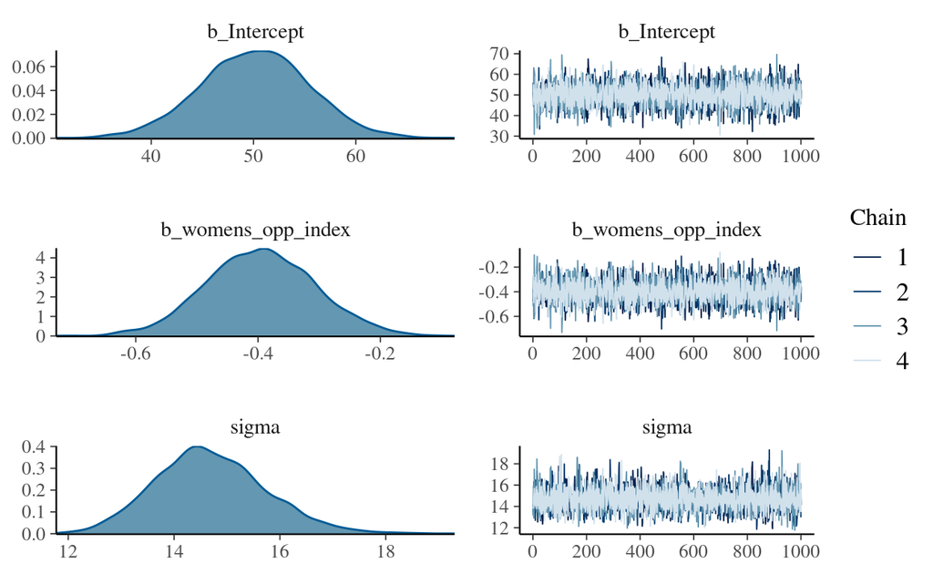

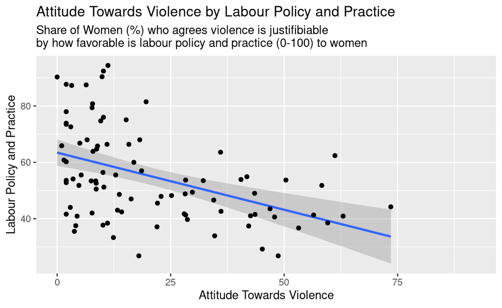

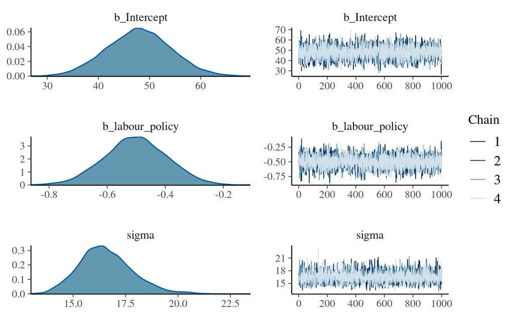

```
 Family: gaussian
  Links: mu = identity; sigma = identity
Formula: attitude ~ labour_policy
   Data: relevant_factors (Number of observations: 89)
  Draws: 4 chains, each with iter = 2000; warmup = 1000; thin = 1;
         total post-warmup draws = 4000

Population-Level Effects:
              Estimate Est.Error l-95% CI u-95% CI Rhat Bulk_ESS
Intercept        47.93      6.23    35.82    60.24 1.00     4205
labour_policy    -0.50      0.11    -0.71    -0.29 1.00     4184
              Tail_ESS
Intercept         2934
labour_policy     2834

Family Specific Parameters:
      Estimate Est.Error l-95% CI u-95% CI Rhat Bulk_ESS Tail_ESS
sigma    16.56      1.27    14.29    19.32 1.00     3971     2906

Draws were sampled using sampling(NUTS). For each parameter, Bulk_ESS
and Tail_ESS are effective sample size measures, and Rhat is the potential
scale reduction factor on split chains (at convergence, Rhat = 1).
```

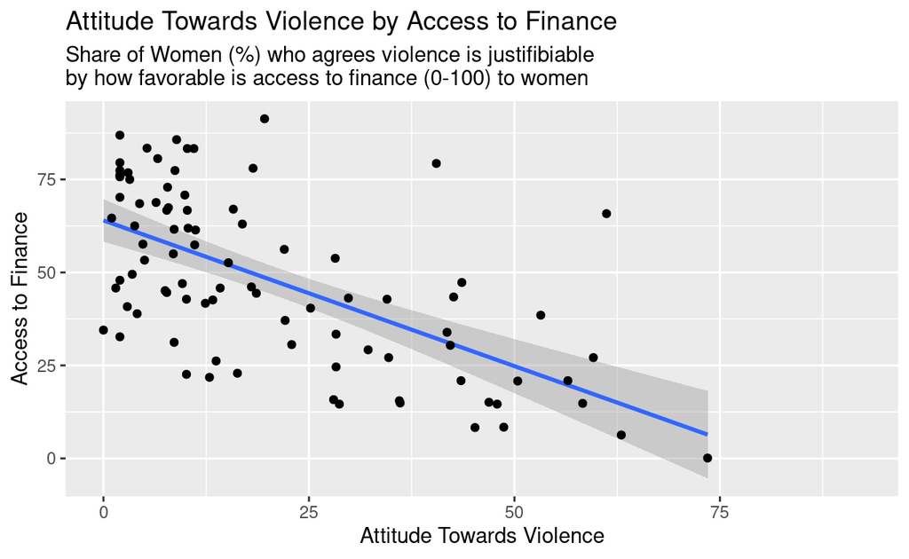

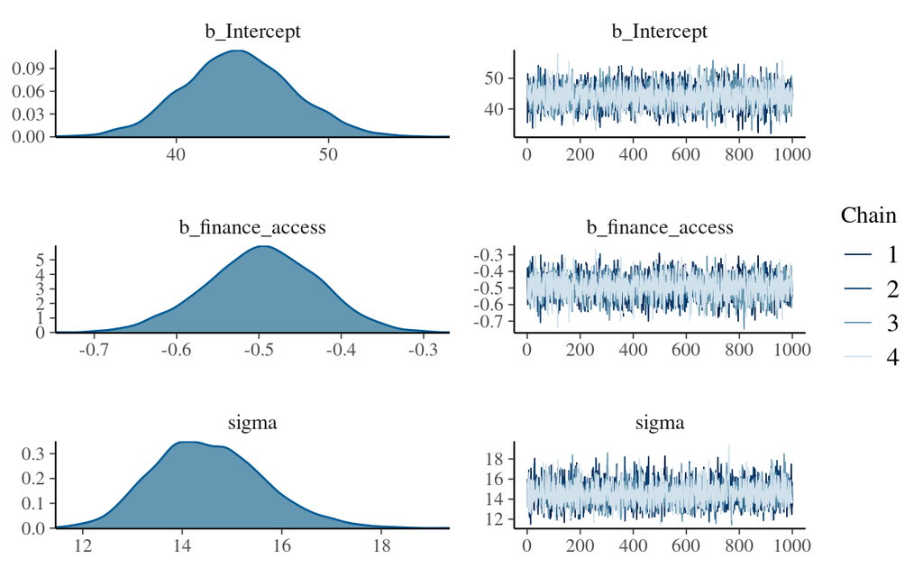

```
 Family: gaussian
  Links: mu = identity; sigma = identity
Formula: attitude ~ finance_access
   Data: relevant_factors (Number of observations: 89)
  Draws: 4 chains, each with iter = 2000; warmup = 1000; thin = 1;
         total post-warmup draws = 4000

Population-Level Effects:
               Estimate Est.Error l-95% CI u-95% CI Rhat Bulk_ESS
Intercept         44.07      3.57    37.08    51.22 1.00     3759
finance_access    -0.50      0.07    -0.63    -0.37 1.00     3927
               Tail_ESS
Intercept          2964
finance_access     2700

Family Specific Parameters:
      Estimate Est.Error l-95% CI u-95% CI Rhat Bulk_ESS Tail_ESS
sigma    14.53      1.11    12.59    16.89 1.00     3621     2940

Draws were sampled using sampling(NUTS). For each parameter, Bulk_ESS
and Tail_ESS are effective sample size measures, and Rhat is the potential
scale reduction factor on split chains (at convergence, Rhat = 1).
```

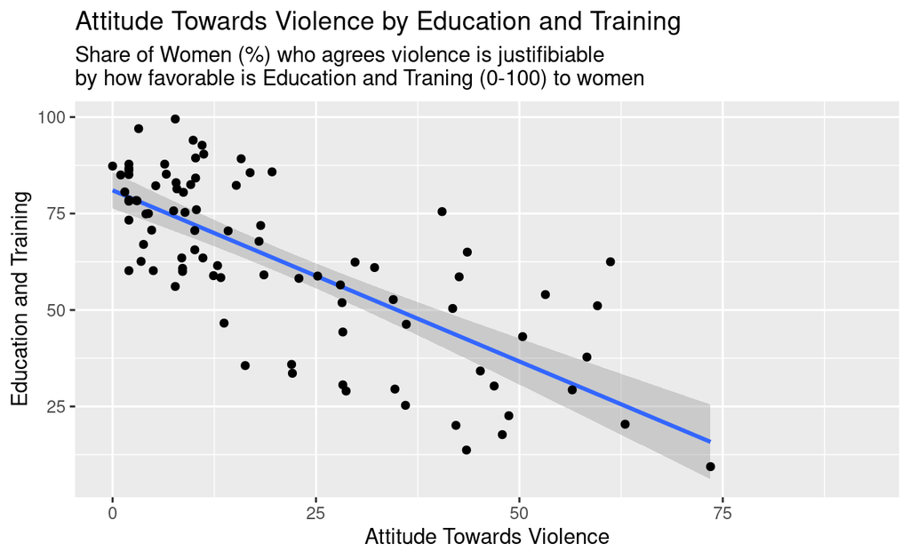

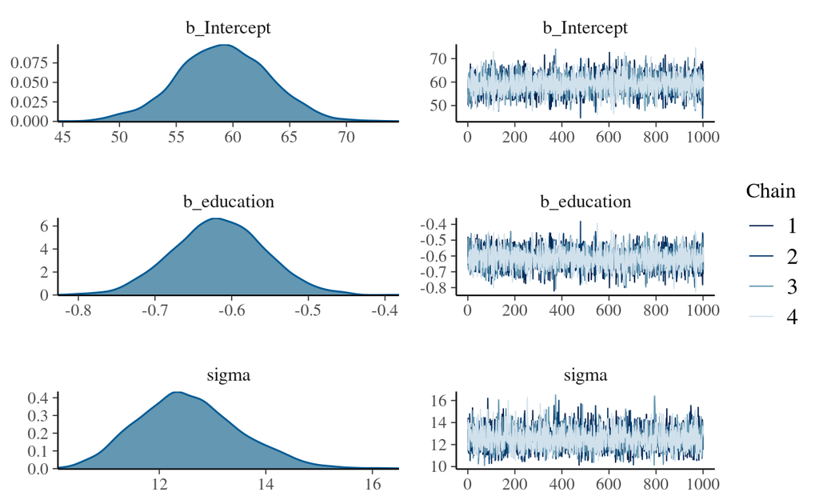

```
 Family: gaussian
  Links: mu = identity; sigma = identity
Formula: attitude ~ education
   Data: relevant_factors (Number of observations: 89)
  Draws: 4 chains, each with iter = 2000; warmup = 1000; thin = 1;
         total post-warmup draws = 4000

Population-Level Effects:
          Estimate Est.Error l-95% CI u-95% CI Rhat Bulk_ESS Tail_ESS
Intercept    59.15      4.03    51.00    66.84 1.00     4321     2648
education    -0.62      0.06    -0.73    -0.50 1.00     4312     2900

Family Specific Parameters:
      Estimate Est.Error l-95% CI u-95% CI Rhat Bulk_ESS Tail_ESS
sigma    12.55      0.96    10.86    14.54 1.00     4036     2982

Draws were sampled using sampling(NUTS). For each parameter, Bulk_ESS
and Tail_ESS are effective sample size measures, and Rhat is the potential
scale reduction factor on split chains (at convergence, Rhat = 1).
```

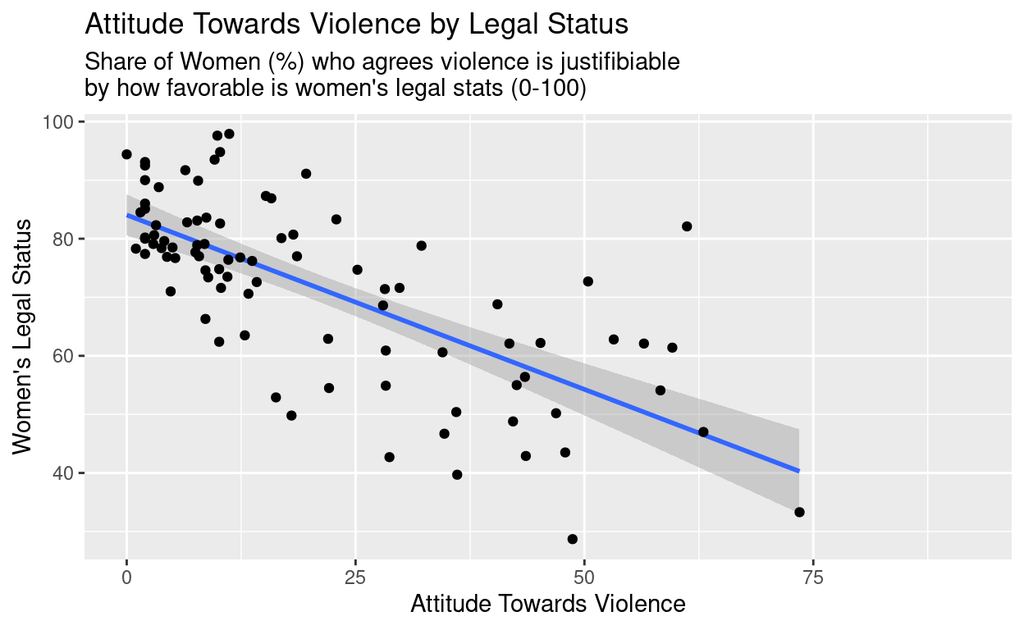

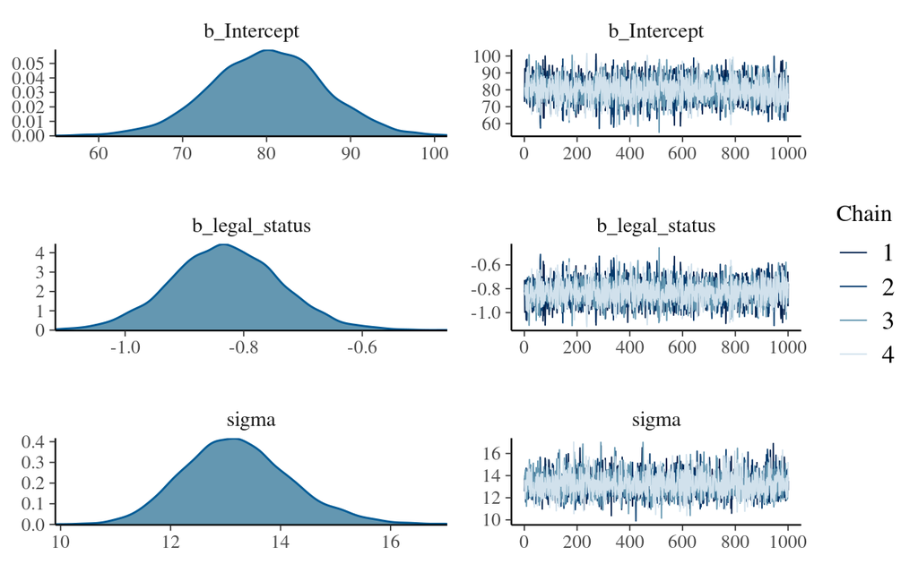

```
 Family: gaussian
  Links: mu = identity; sigma = identity
Formula: attitude ~ legal_status
   Data: relevant_factors (Number of observations: 89)
  Draws: 4 chains, each with iter = 2000; warmup = 1000; thin = 1;
         total post-warmup draws = 4000

Population-Level Effects:
             Estimate Est.Error l-95% CI u-95% CI Rhat Bulk_ESS
Intercept       80.07      6.73    66.45    93.24 1.00     3854
legal_status    -0.83      0.09    -1.01    -0.65 1.00     3836
             Tail_ESS
Intercept        2815
legal_status     2811

Family Specific Parameters:
      Estimate Est.Error l-95% CI u-95% CI Rhat Bulk_ESS Tail_ESS
sigma    13.22      0.98    11.46    15.30 1.00     3788     3117

Draws were sampled using sampling(NUTS). For each parameter, Bulk_ESS
and Tail_ESS are effective sample size measures, and Rhat is the potential
scale reduction factor on split chains (at convergence, Rhat = 1).
```

With those results in mind, we draw a multivariate regression:

[figure not shown]

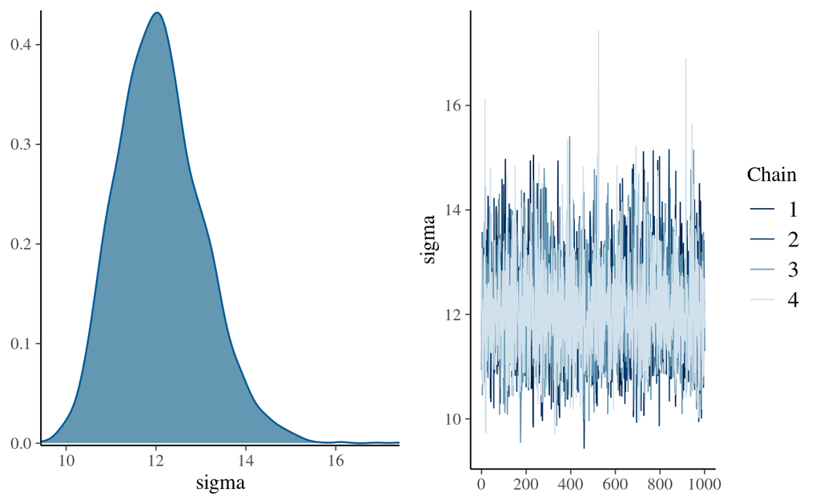

```
 Family: gaussian
  Links: mu = identity; sigma = identity
Formula: attitude ~ labour_policy + education + legal_status + finance_access
   Data: relevant_factors (Number of observations: 89)
  Draws: 4 chains, each with iter = 2000; warmup = 1000; thin = 1;
         total post-warmup draws = 4000

Population-Level Effects:
               Estimate Est.Error l-95% CI u-95% CI Rhat Bulk_ESS
Intercept         69.82      6.55    57.04    82.69 1.00     4194
labour_policy      0.21      0.11    -0.02     0.43 1.00     4379
education         -0.42      0.13    -0.67    -0.17 1.00     3183
legal_status      -0.45      0.16    -0.76    -0.14 1.00     3790
finance_access    -0.04      0.10    -0.23     0.15 1.00     3796
               Tail_ESS
Intercept          3511
labour_policy      2877
education          2947
legal_status       3008
finance_access     2855

Family Specific Parameters:
      Estimate Est.Error l-95% CI u-95% CI Rhat Bulk_ESS Tail_ESS
sigma    12.09      0.95    10.46    14.15 1.00     3743     2707

Draws were sampled using sampling(NUTS). For each parameter, Bulk_ESS
and Tail_ESS are effective sample size measures, and Rhat is the potential
scale reduction factor on split chains (at convergence, Rhat = 1).
```

# Limitations of Independent Variable

The variables we have explored in the Women’s Economic Index Composite index are composite variables. Hence, even if we are looking for one specific variable that could particularly be causing higher levels of Attitude Towards Violence, this would not particularly be helpful. We would have to pay attention to the variables behind the larger indicators we are investigating. Besides that, being composite variables give large possibility of confounding variables to complicate our analysis. In other words, all the subcategories for each indicator are correlated, thus increasing the chances of having an unseen confounding variable.

Similar data limitations with our dependent variables return here, as well. The index has the very complicated way to measure an abstract concept such as “women’s economic opportunities.” Selecting which variables are put together to form one single indicator involves many human biases and interested/bias decisions. For example, since the indicator is developed by The Economist, many of the variables hint that they particularly considered important private sector entrepreneurship and initiatives as a measure for women’s opportunities. Same is applied to the importance they seem to attach in women’s entrance in finance and business. There could possibly been equally rigorous indexed that take into acount public policy and state-sponsored opportunities.

This is also connected with the fact that many of the qualitative indicators were created by the Economist Intelligence Unit rather than being collected by national statistics sources, which might further increase human and organizational bias in the collection and analysis of the data.

A final limitation is that our independent variable only includes 128 countries.

# Analysis and Interpretation of Results

A counterfactual that arises from our research is imagining a country in which the women’s legal status was signficantly lower than the rest of the indicators. Would such a country have lower levels of attitude against violence (less women agreeing that violence is justified)? Even though we cannot find such a case within the indicators of the WOEI, the exploration on the dependent variables highlighted the Russian Federation as having laws on domestic violence that completely discriminated against women but had decent levels in prevalence of violence in lifetime and attitude towards women. A further study on the case of the Russian Federation could reveal the effectiveness of women’s legal status (and especifically laws against domestic violence) in causing a decrease in violence against women.

# Conclusions

We cannot single out or highlight one single indicator in the WEOI that is most influential in decreasing violence against women. Our research highlights the complexities and the varying number of factors that result in the persistence of violence against women. However, it still might be useful to investigate further the sub-indicators within each indicator for the WEOI and analyze what they can provide as insights. Singling out countries, like Russia, and analyze closely what is the situation in violence against women through both quantitative and qualitative research can further reveal indicators that can be useful in measuring degrees of such forms of gendered violence.

# Bibliography

Pathak, S., Goltz, S. and W. Buche, M. “Influences of gendered institutions on women ’ s entry into entrepreneurship”, International Journal of Entrepreneurial Behavior & Research. 19:5 (2013), 478-502. https://doi.org/10.1108/IJEBR-09-2011-0115 Acker, Joan. “HIERARCHIES, JOBS, BODIES: A Theory of Gendered Organizations.” Gender and Society. 4:2 (1990): 139-158 Okenwa-Emgwa, L., von Strauss, E. Higher education as a platform for capacity building to address violence against women and promote gender equality: the Swedish example. Public Health Rev 39, 31 (2018). https://doi.org/10.1186/s40985-018-0108-5 Tavares, Paula and Question Wodon.”Global and Regional Trends in Women’s Legal Protection Against Domestic Violence and Sexual Harassment.” March 2018. Girl Rising